# Extracting Maximum Likelihood Points For The Cores

The point is to use the “core genes” (the ones that are always in the core in accordance with all regression comparisons) to calculate the Maximum Likelihood centers of the cores. The data for this script comes from here. Be sure to have the output freshly generated in case you use some ambigous naming in other scripts and could have overriden the files.

```r
library("gbra") #becaus gbra has the function AND it loads plyr, dplyr, data.table, etc.
if(!require("ape")){
  install.packages("ape")
  library("ape")
}
if(!require("stringr")){
  install.packages("stringr")
  library("stringr")
}
if(!require("Rphylip")){
  install.packages("Rphylip")
  library("Rphylip")
}
if(!require("doParallel")){
  install.packages("doParallel")
  library("doParallel")
}
self.dir<- "extracting.mle.for.cores.output"
if(!file.exists(self.dir)){
  dir.create(self.dir)
}
self.dir.folder<- function(file=""){
  return(paste(self.dir, file, sep="/"))
}
```

```r
#first of all - legend
legend<-load.legend(legend.file = "/home/alext/Developer/gbra/inst/extradata/legend.csv",sep = "\t")
#this table contains all the names in the "gene.name" column
master.table.core.always.core<-read.table(file="master.table.core.always.core.txt", header = TRUE, sep = "\t")
#read the data itself
bh.data.core<-read.table(file="bh.data.minhit_4.txt", header = TRUE, sep="\t")
#select only core genes from the data
bh.data.core.only<-bh.data.core[as.character(master.table.core.always.core$gene.name),]
#attach genome ids to the end (apparently fast enough to run one thread)
bh.data.core.only$ID_QUERY_GENOME<-sapply(rownames(bh.data.core.only),function(i){
  return(strsplit(i,"X",fixed = TRUE)[[1]][1])
})
#wee need the ID_QUERY_ORF column and ID_QUERY_GENOME columns in front of the dataframe to get the MLEs with a standard function
bh.data.core.only$ID_QUERY_ORF<-rownames(bh.data.core.only)
#placind the ID columns in front of the table
bh.data.core.only <- bh.data.core.only[, c(ncol(bh.data.core.only),(ncol(bh.data.core.only)-1),1:nrow(legend))]
```

Now it is time to calculate an MLE estimate for each genome.

```r
#Calculate MLEs
genome.mles<-getMLEs(df = bh.data.core.only)
```

```
## Calculating MLE for genome 1
## Calculating MLE for genome 10
## Calculating MLE for genome 11
## Calculating MLE for genome 12
## Calculating MLE for genome 13
## Calculating MLE for genome 14
## Calculating MLE for genome 15
## Calculating MLE for genome 16
## Calculating MLE for genome 17
## Calculating MLE for genome 18
## Calculating MLE for genome 19
## Calculating MLE for genome 2
## Calculating MLE for genome 20
## Calculating MLE for genome 21
## Calculating MLE for genome 22
## Calculating MLE for genome 23
## Calculating MLE for genome 24
## Calculating MLE for genome 25
## Calculating MLE for genome 26
## Calculating MLE for genome 27
## Calculating MLE for genome 28
## Calculating MLE for genome 3
## Calculating MLE for genome 30
## Calculating MLE for genome 31
## Calculating MLE for genome 32
## Calculating MLE for genome 33
## Calculating MLE for genome 34
## Calculating MLE for genome 35
## Calculating MLE for genome 36
## Calculating MLE for genome 37
## Calculating MLE for genome 38
## Calculating MLE for genome 39
## Calculating MLE for genome 4
## Calculating MLE for genome 40
## Calculating MLE for genome 41
## Calculating MLE for genome 42
## Calculating MLE for genome 43
## Calculating MLE for genome 44
## Calculating MLE for genome 45
## Calculating MLE for genome 46
## Calculating MLE for genome 5
## Calculating MLE for genome 6
## Calculating MLE for genome 7
## Calculating MLE for genome 8
## Calculating MLE for genome 9
```

```r
#get the gprimes
genome.gprimes<-extract.gprimes(mle.list = genome.mles)
#format the rownames to have exactly the number of spaces fitch wants to have
rownames(genome.gprimes)<-sapply(rownames(genome.gprimes), function(i){
  rn<-str_pad(i, 12, side = "right",pad = " ")
  return(rn)
})
#distance matrix
genome.mle.dist<-as.matrix(dist(genome.gprimes))
head(genome.mle.dist)
```

```
##              X1           X10          X11          X12
## X1               0.000000     1.446905     1.482017     1.462069
## X10              1.446905     0.000000     1.306671     1.087902
## X11              1.482017     1.306671     0.000000     1.311579
## X12              1.462069     1.087902     1.311579     0.000000
## X13              1.417605     1.313868     1.306542     1.318102
## X14              1.537028     1.432372     1.424721     1.429743
##              X13          X14          X15          X16
## X1               1.417605     1.537028     1.529103     1.336885
## X10              1.313868     1.432372     1.293480     1.465597
## X11              1.306542     1.424721     1.303810     1.478457
## X12              1.318102     1.429743     1.299249     1.480268
## X13              0.000000     1.414249     1.354072     1.449908
## X14              1.414249     0.000000     1.445863     1.544998
##              X17          X18          X19          X2
## X1               1.522203     1.329912     1.395532     1.096149
## X10              1.450086     1.455240     1.470510     1.455734
## X11              1.444673     1.473186     1.483998     1.488179
## X12              1.458107     1.468450     1.483755     1.469741
## X13              1.428225     1.432901     1.462100     1.424472
## X14              1.217021     1.537238     1.547367     1.544495
##              X20          X21          X22          X23
## X1               1.517724    1.5516465     1.514712     1.689910
## X10              1.211452    1.4345121     1.417582     1.590537
## X11              1.388103    1.4297336     1.411914     1.577712
## X12              1.176555    1.4300920     1.420250     1.594406
## X13              1.366217    1.4214529     1.408388     1.552549
## X14              1.447297    0.9923731     1.243979     1.725752
##              X24          X25          X26          X27
## X1               1.374494     1.377935     1.471115     1.457602
## X10              1.468695     1.482668     1.352529     1.315364
## X11              1.484219     1.497363     1.364499     1.341177
## X12              1.482420     1.495378     1.351905     1.305696
## X13              1.456166     1.470171     1.330655     1.317459
## X14              1.549761     1.569131     1.345689     1.337640
##              X28          X3           X30          X31
## X1               1.175652     1.463105     1.532916     1.419846
## X10              1.545200     1.704496     1.470974     1.174047
## X11              1.566328     1.726029     1.464858     1.350358
## X12              1.560659     1.714788     1.480315     1.147508
```

[output cut: 29 more lines]

```
## X14              1.394521    0.8627774     1.520982     1.469095
##              X5           X6           X7           X8
## X1               1.160955     1.578388     1.595171     1.406438
## X10              1.432020     1.512440     1.510744     1.311798
## X11              1.464685     1.506116     1.505961     1.300570
## X12              1.443327     1.518716     1.517867     1.311805
## X13              1.401681     1.494182     1.458299     1.237849
## X14              1.501967     1.104099     1.552599     1.413812
##              X9
## X1               1.514263
## X10              1.383767
## X11              1.381862
## X12              1.378467
## X13              1.372675
## X14              1.197313
```

```r
#write out as fitch output
write.fitch(dist.mtx = genome.mle.dist, file=self.dir.folder("core.mle.distance.matrix"))
```

```r
write.table(x=genome.mle.dist, file=self.dir.folder("genome.mle.dist.txt"), sep = "\t", quote = FALSE)
```

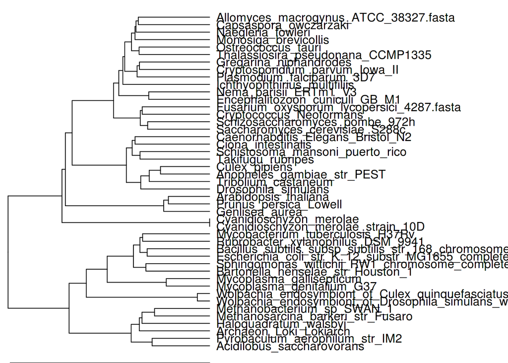

```r
#assign proper names to the rows
genome.mle.dist.for.plot<-genome.mle.dist
rownames(genome.mle.dist.for.plot)<-sapply(rownames(genome.mle.dist),function(i){return(legend$name[which(legend$id_genomes==str_trim(strsplit(i,"X",fixed=TRUE)[[1]][2]))])})
par(mar=c(0,0,0,20), oma=rep(0,4))
plot(as.dendrogram(hclust(as.dist(genome.mle.dist.for.plot),method = "ward.D2")), horiz=TRUE)
```

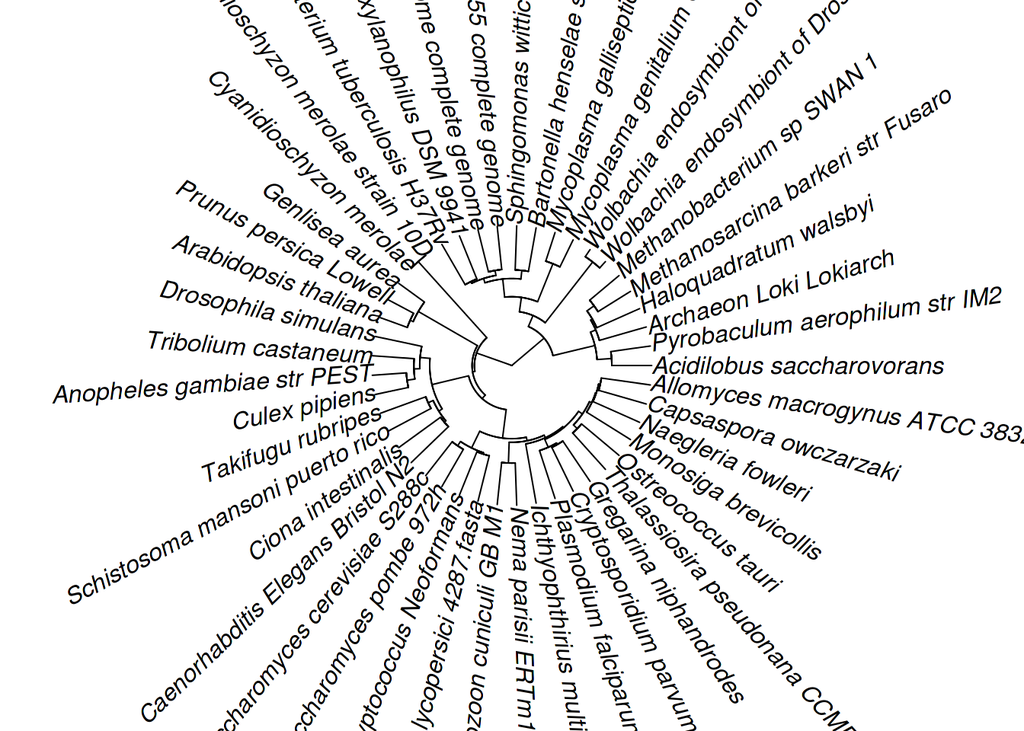

```r
par(mar=rep(0,4), oma=rep(0,4))
plot(as.phylo(hclust(as.dist(genome.mle.dist.for.plot),method = "ward.D2")), type = "fan")
```

So, at this point, it appeared so, that the the hclust is not ideal for the tree generation, and that is why the futher idea is to generate a tree, where the **“outsider”** genomes will participate as **“separate”** organisms.

```r
#load the frequent outsiders
master.table.core.outsider.frequently<-read.table(file="master.table.core.outsider.frequently.txt", header=TRUE, sep="\t")
#load the facultative outsiders
master.table.core.outsider.once<-read.table(file="master.table.core.outsider.once.txt", header=TRUE, sep="\t")
#outsider table
master.table.outsiders<-bh.data.core[unique(as.character(master.table.core.outsider.once$gene.name), as.character(master.table.core.outsider.frequently$gene.name)),]
master.table.outsiders$ID_QUERY_ORF<-rownames(master.table.outsiders)
master.table.outsiders$ID_QUERY_GENOME<-sapply(rownames(master.table.outsiders), function(i){
  return(strsplit(i,"X", fixed=TRUE)[[1]][1])
})
master.table.outsiders<-master.table.outsiders[,c((ncol(master.table.outsiders)-1),ncol(master.table.outsiders),1:nrow(legend))]
#calculate mles
outsider.mles<-getMLEs(df = master.table.outsiders)
```

```
## Calculating MLE for genome 1
## Calculating MLE for genome 10
## Calculating MLE for genome 11
## Calculating MLE for genome 12
## Calculating MLE for genome 13
## Calculating MLE for genome 14
## Calculating MLE for genome 15
## Calculating MLE for genome 16
## Calculating MLE for genome 17
## Calculating MLE for genome 18
## Calculating MLE for genome 19
## Calculating MLE for genome 2
## Calculating MLE for genome 20
## Calculating MLE for genome 21
## Calculating MLE for genome 22
## Calculating MLE for genome 23
## Calculating MLE for genome 24
## Calculating MLE for genome 25
## Calculating MLE for genome 26
## Calculating MLE for genome 27
## Calculating MLE for genome 28
## Calculating MLE for genome 3
## Calculating MLE for genome 30
## Calculating MLE for genome 31
## Calculating MLE for genome 32
## Calculating MLE for genome 33
## Calculating MLE for genome 34
## Calculating MLE for genome 35
## Calculating MLE for genome 36
## Calculating MLE for genome 37
## Calculating MLE for genome 38
## Calculating MLE for genome 39
## Calculating MLE for genome 4
## Calculating MLE for genome 40
## Calculating MLE for genome 41
## Calculating MLE for genome 42
## Calculating MLE for genome 43
## Calculating MLE for genome 44
## Calculating MLE for genome 45
## Calculating MLE for genome 46
## Calculating MLE for genome 5
## Calculating MLE for genome 6
## Calculating MLE for genome 7
## Calculating MLE for genome 8
## Calculating MLE for genome 9
```

```r
#get the gprimes
outsider.gprimes<-extract.gprimes(mle.list = outsider.mles)
head(outsider.gprimes)
```

```
##             X1        X10        X11        X12        X13        X14
## X1  1.00000000 0.02478363 0.01830923 0.03055882 0.03627331 0.03202880
## X10 0.04592181 1.00000000 0.09175526 0.17348887 0.12054314 0.16036319
## X11 0.01552491 0.09265098 1.00000000 0.07286637 0.09633470 0.17953233
## X12 0.04672536 0.18421927 0.07434002 1.00000000 0.12329663 0.18483000
## X13 0.16480660 0.09639856 0.05537109 0.09103102 1.00000000 0.06489217
## X14 0.02299601 0.07631141 0.04138886 0.05900366 0.07861100 0.99965818
##            X15        X16         X17        X18         X19         X2
## X1  0.00994393 0.04694152 0.003594094 0.03369992 0.016657185 0.07368901
## X10 0.04632171 0.03760369 0.041069414 0.03162932 0.022614221 0.04350885
## X11 0.05382070 0.03292829 0.046588465 0.01799968 0.016772777 0.01888393
## X12 0.03820066 0.02460270 0.056547484 0.02074422 0.016073370 0.03031251
## X13 0.02909537 0.17831571 0.010299236 0.11520231 0.069391192 0.17477635
## X14 0.02641215 0.02439421 0.079248544 0.01068835 0.008641948 0.02477906
##            X20        X21        X22        X23        X24        X25
## X1  0.01078174 0.01738556 0.01483975 0.04258028 0.02508041 0.03449213
## X10 0.10677156 0.12432856 0.06756059 0.13895584 0.02351071 0.03052953
## X11 0.04753714 0.13291894 0.05180253 0.10395310 0.02052687 0.02332493
## X12 0.09399195 0.13633056 0.06707196 0.10912533 0.01726380 0.01617053
## X13 0.03507643 0.05191594 0.02836674 0.12242121 0.07746556 0.12491662
## X14 0.08601008 0.15226125 0.05181542 0.07461018 0.00961321 0.01059833
##            X26        X27         X28         X3         X30        X31
## X1  0.01558154 0.02177856 0.055076863 0.05477792 0.005898322 0.03415093
## X10 0.08670491 0.12766003 0.024795512 0.02285942 0.038855641 0.19557139
## X11 0.08205732 0.10276958 0.009839516 0.01131806 0.028675214 0.08889967
## X12 0.09048835 0.15536518 0.025423915 0.02940776 0.050473061 0.18668685
## X13 0.03663407 0.06758314 0.090398800 0.06363936 0.010231346 0.09627654
## X14 0.07960710 0.08190274 0.012037301 0.01816191 0.031627450 0.11248482
##            X32        X33         X34         X35        X36        X37
## X1  0.02087389 0.05376318 0.011142088 0.012085908 0.06973866 0.00681896
## X10 0.14434627 0.03870233 0.007172250 0.009574566 0.04126000 0.04041176
## X11 0.11039744 0.01527264 0.003111442 0.003865984 0.01644439 0.05161199
## X12 0.16365472 0.03448937 0.006625715 0.008206571 0.02710665 0.04697234
## X13 0.07255828 0.14206308 0.026057879 0.033349776 0.14551615 0.02440691
## X14 0.11041676 0.01961517 0.003972617 0.006604713 0.02286652 0.02635588
##            X38        X39         X4         X40        X41        X42
## X1  0.04258028 0.01572932 0.06813588 0.001090719 0.02504265 0.02611835
## X10 0.13895584 0.07981180 0.02381887 0.008633855 0.11882330 0.13233740
## X11 0.10395310 0.09132765 0.01039709 0.009827785 0.07526479 0.12260033
## X12 0.10912533 0.07302034 0.02797715 0.006723491 0.12416027 0.12392018
## X13 0.12242121 0.06171134 0.07507234 0.002832143 0.06507613 0.08758055
## X14 0.07461018 0.06557109 0.01627526 0.010949534 0.13381201 0.05802556
##            X43        X44        X45        X46         X5          X6
## X1  0.02137788 0.03333382 0.03303687 0.02344732 0.09329403 0.003651902
## X10 0.07800202 0.16412919 0.03273340 0.12401045 0.04719123 0.039410671
## X11 0.11279981 0.17525658 0.02020870 0.08059421 0.01832366 0.039733867
## X12 0.08254649 0.17792309 0.01852025 0.11320375 0.04255432 0.033296554
## X13 0.06932616 0.06346646 0.11615926 0.05426288 0.15489933 0.011826184
## X14 0.05400150 0.22980728 0.01394301 0.14134061 0.02024898 0.067254281
##             X7         X8          X9
## X1  0.02417418 0.05598794 0.009367118
## X10 0.11776255 0.14598583 0.079581028
## X11 0.07211093 0.13168986 0.093581543
## X12 0.14075633 0.12016950 0.091466565
## X13 0.05882846 0.12042528 0.051165461
## X14 0.16714610 0.08564236 0.098284552
```

```r
#substitute the "X" for "Y" to distinguish from genomes
rownames(outsider.gprimes)<-sapply(rownames(outsider.gprimes),function(i){
  return(paste0("Y",strsplit(i,"X",fixed=TRUE)[[1]][2]))
})
rownames(outsider.gprimes)<-sapply(rownames(outsider.gprimes), function(i){
  rn<-str_pad(i, 12, side = "right",pad = " ")
  return(rn)
})
colnames(outsider.gprimes)<-rownames(outsider.gprimes)
#combine with with genomes
total.mles<-rbind(genome.gprimes,outsider.gprimes)
#distance
total.dist<-as.matrix(dist(total.mles))
#write out as fitch output
write.fitch(dist.mtx = total.dist, file=self.dir.folder("total.dist.txt"))
```

Now, we decided to try the cutoff 3 for an outsider to be considered “outsider”.

```r
#select those that appear as outsiders 3 and more times
master.table.outsiders.3.cutoff <- master.table.core.outsider.frequently %>% filter(outsider>=3)
#select the corresponding data
bh.data.3.cutoff<- bh.data.core[as.character(master.table.outsiders.3.cutoff$gene.name),]
head(bh.data.3.cutoff)
```

```
##       X1       X10       X11       X12        X13       X14       X15
## 1X10   1 0.0000000 0.0000000 0.1246878 0.00000000 0.0000000 0.0000000
## 1X37   1 0.4630956 0.0000000 0.4823662 0.43776358 0.4515304 0.0000000
## 1X39   1 0.0000000 0.0000000 0.0000000 0.20793243 0.0000000 0.0000000
## 1X164  1 0.1136791 0.0000000 0.1316854 0.09788369 0.1220213 0.0000000
## 1X453  1 0.1890929 0.2023176 0.1469109 0.13165362 0.1519923 0.0000000
## 1X638  1 0.1528537 0.1512289 0.1607664 0.16169658 0.1491329 0.1437813
##              X16       X17       X18       X19        X2       X20
## 1X10  0.00000000 0.0000000 0.1484445 0.0000000 0.1549656 0.0000000
## 1X37  0.00000000 0.1299338 0.0000000 0.0000000 0.0000000 0.1530643
## 1X39  0.00000000 0.0000000 0.0000000 0.0000000 0.0000000 0.0000000
## 1X164 0.09305161 0.0000000 0.0000000 0.2848872 0.0000000 0.0000000
## 1X453 0.00000000 0.0000000 0.2221284 0.1702720 0.2963559 0.0000000
## 1X638 0.00000000 0.0000000 0.0000000 0.0000000 0.0000000 0.1116715
##             X21       X22       X23       X24       X25       X26
## 1X10  0.0000000 0.0000000 0.0000000 0.1365584 0.0000000 0.0000000
## 1X37  0.4140899 0.1497620 0.0000000 0.0000000 0.0000000 0.0000000
## 1X39  0.2116275 0.0000000 0.2033016 0.0000000 0.0000000 0.0000000
## 1X164 0.1123685 0.0000000 0.1110465 0.2914744 0.0000000 0.1246538
## 1X453 0.3919648 0.6212467 0.1260707 0.0000000 0.2536592 0.1423311
## 1X638 0.1502926 0.1500631 0.1372639 0.0000000 0.0000000 0.1449471
##             X27       X28       X3        X30       X31       X32
## 1X10  0.0000000 0.0000000 0.000000 0.00000000 0.0000000 0.0000000
## 1X37  0.5220083 0.1150663 0.000000 0.00000000 0.3011966 0.5423940
## 1X39  0.0000000 0.0000000 0.000000 0.00000000 0.0000000 0.0000000
## 1X164 0.0000000 0.1242208 0.000000 0.00000000 0.1150011 0.1031488
## 1X453 0.1423311 0.2155424 0.249581 0.00000000 0.1260707 0.1357187
## 1X638 0.1565805 0.0000000 0.000000 0.05769614 0.1626268 0.1519235
##             X33 X34 X35       X36       X37       X38       X39        X4
## 1X10  0.1246878   0   0 0.0000000 0.0000000 0.0000000 0.0000000 0.0000000
## 1X37  0.0000000   0   0 0.0000000 0.0000000 0.0000000 0.0000000 0.0000000
## 1X39  0.0000000   0   0 0.0000000 0.0000000 0.2033016 0.0000000 0.0000000
## 1X164 0.0000000   0   0 0.0000000 0.0000000 0.1110465 0.0000000 0.0000000
## 1X453 0.0000000   0   0 0.2378872 0.0000000 0.1260707 0.1992556 0.2505972
## 1X638 0.0000000   0   0 0.0000000 0.1340082 0.1372639 0.1414558 0.0000000
##              X40       X41       X42       X43       X44 X45       X46
## 1X10  0.00000000 0.1668517 0.0000000 0.1276323 0.0000000   0 0.1656646
## 1X37  0.00000000 0.0000000 0.2285028 0.3469000 0.5165044   0 0.0000000
## 1X39  0.00000000 0.0000000 0.0000000 0.0000000 0.0000000   0 0.0000000
## 1X164 0.00000000 0.0000000 0.1422157 0.0000000 0.1308079   0 0.0000000
## 1X453 0.00000000 0.1214645 0.2216400 0.2068975 0.1438621   0 0.0000000
## 1X638 0.05210894 0.1449471 0.1675133 0.1516940 0.1488974   0 0.1537839
##              X5        X6        X7        X8        X9
## 1X10  0.0000000 0.0000000 0.1644775 0.1258749 0.0000000
## 1X37  0.0000000 0.4476705 0.0000000 0.1398550 0.2196966
## 1X39  0.0000000 0.0000000 0.0000000 0.0000000 0.0000000
## 1X164 0.1018268 0.0000000 0.0000000 0.0000000 0.0000000
## 1X453 0.2063959 0.0000000 0.0000000 0.1326699 0.3380627
## 1X638 0.3220039 0.1288922 0.1628623 0.1831031 0.1351740
```

```r
#same stuff - attach the id-columns and sort so that the id-columns appear in the beginning
bh.data.3.cutoff$ID_QUERY_ORF<-rownames(bh.data.3.cutoff)
bh.data.3.cutoff$ID_QUERY_GENOME<-sapply(rownames(bh.data.3.cutoff), function(i){
  return(strsplit(i,"X", fixed=TRUE)[[1]][1])
})
bh.data.3.cutoff <- bh.data.3.cutoff[,c((ncol(bh.data.3.cutoff)-1),ncol(bh.data.3.cutoff),1:nrow(legend))]
head(bh.data.3.cutoff)
```

```
##       ID_QUERY_ORF ID_QUERY_GENOME X1       X10       X11       X12
## 1X10          1X10               1  1 0.0000000 0.0000000 0.1246878
## 1X37          1X37               1  1 0.4630956 0.0000000 0.4823662
## 1X39          1X39               1  1 0.0000000 0.0000000 0.0000000
## 1X164        1X164               1  1 0.1136791 0.0000000 0.1316854
## 1X453        1X453               1  1 0.1890929 0.2023176 0.1469109
## 1X638        1X638               1  1 0.1528537 0.1512289 0.1607664
##              X13       X14       X15        X16       X17       X18
## 1X10  0.00000000 0.0000000 0.0000000 0.00000000 0.0000000 0.1484445
## 1X37  0.43776358 0.4515304 0.0000000 0.00000000 0.1299338 0.0000000
## 1X39  0.20793243 0.0000000 0.0000000 0.00000000 0.0000000 0.0000000
## 1X164 0.09788369 0.1220213 0.0000000 0.09305161 0.0000000 0.0000000
## 1X453 0.13165362 0.1519923 0.0000000 0.00000000 0.0000000 0.2221284
## 1X638 0.16169658 0.1491329 0.1437813 0.00000000 0.0000000 0.0000000
##             X19        X2       X20       X21       X22       X23
## 1X10  0.0000000 0.1549656 0.0000000 0.0000000 0.0000000 0.0000000
## 1X37  0.0000000 0.0000000 0.1530643 0.4140899 0.1497620 0.0000000
## 1X39  0.0000000 0.0000000 0.0000000 0.2116275 0.0000000 0.2033016
## 1X164 0.2848872 0.0000000 0.0000000 0.1123685 0.0000000 0.1110465
## 1X453 0.1702720 0.2963559 0.0000000 0.3919648 0.6212467 0.1260707
## 1X638 0.0000000 0.0000000 0.1116715 0.1502926 0.1500631 0.1372639
##             X24       X25       X26       X27       X28       X3
## 1X10  0.1365584 0.0000000 0.0000000 0.0000000 0.0000000 0.000000
## 1X37  0.0000000 0.0000000 0.0000000 0.5220083 0.1150663 0.000000
## 1X39  0.0000000 0.0000000 0.0000000 0.0000000 0.0000000 0.000000
## 1X164 0.2914744 0.0000000 0.1246538 0.0000000 0.1242208 0.000000
## 1X453 0.0000000 0.2536592 0.1423311 0.1423311 0.2155424 0.249581
## 1X638 0.0000000 0.0000000 0.1449471 0.1565805 0.0000000 0.000000
##              X30       X31       X32       X33 X34 X35       X36       X37
## 1X10  0.00000000 0.0000000 0.0000000 0.1246878   0   0 0.0000000 0.0000000
## 1X37  0.00000000 0.3011966 0.5423940 0.0000000   0   0 0.0000000 0.0000000
## 1X39  0.00000000 0.0000000 0.0000000 0.0000000   0   0 0.0000000 0.0000000
## 1X164 0.00000000 0.1150011 0.1031488 0.0000000   0   0 0.0000000 0.0000000
## 1X453 0.00000000 0.1260707 0.1357187 0.0000000   0   0 0.2378872 0.0000000
## 1X638 0.05769614 0.1626268 0.1519235 0.0000000   0   0 0.0000000 0.1340082
##             X38       X39        X4        X40       X41       X42
## 1X10  0.0000000 0.0000000 0.0000000 0.00000000 0.1668517 0.0000000
## 1X37  0.0000000 0.0000000 0.0000000 0.00000000 0.0000000 0.2285028
## 1X39  0.2033016 0.0000000 0.0000000 0.00000000 0.0000000 0.0000000
## 1X164 0.1110465 0.0000000 0.0000000 0.00000000 0.0000000 0.1422157
## 1X453 0.1260707 0.1992556 0.2505972 0.00000000 0.1214645 0.2216400
## 1X638 0.1372639 0.1414558 0.0000000 0.05210894 0.1449471 0.1675133
##             X43       X44 X45       X46        X5        X6        X7
## 1X10  0.1276323 0.0000000   0 0.1656646 0.0000000 0.0000000 0.1644775
## 1X37  0.3469000 0.5165044   0 0.0000000 0.0000000 0.4476705 0.0000000
## 1X39  0.0000000 0.0000000   0 0.0000000 0.0000000 0.0000000 0.0000000
## 1X164 0.0000000 0.1308079   0 0.0000000 0.1018268 0.0000000 0.0000000
## 1X453 0.2068975 0.1438621   0 0.0000000 0.2063959 0.0000000 0.0000000
## 1X638 0.1516940 0.1488974   0 0.1537839 0.3220039 0.1288922 0.1628623
##              X8        X9
## 1X10  0.1258749 0.0000000
## 1X37  0.1398550 0.2196966
## 1X39  0.0000000 0.0000000
## 1X164 0.0000000 0.0000000
## 1X453 0.1326699 0.3380627
## 1X638 0.1831031 0.1351740
```

```r
#get mles
outsider.3.cutoff<- getMLEs(df = bh.data.3.cutoff)
```

```
## Calculating MLE for genome 1
## Calculating MLE for genome 10
## Calculating MLE for genome 11
## Calculating MLE for genome 12
## Calculating MLE for genome 13
## Calculating MLE for genome 14
## Calculating MLE for genome 15
## Calculating MLE for genome 16
## Calculating MLE for genome 17
## Calculating MLE for genome 18
## Calculating MLE for genome 19
## Calculating MLE for genome 2
## Calculating MLE for genome 20
## Calculating MLE for genome 21
## Calculating MLE for genome 22
## Calculating MLE for genome 24
## Calculating MLE for genome 25
## Calculating MLE for genome 26
## Calculating MLE for genome 27
## Calculating MLE for genome 28
## Calculating MLE for genome 3
## Calculating MLE for genome 30
## Calculating MLE for genome 31
## Calculating MLE for genome 32
## Calculating MLE for genome 33
## Calculating MLE for genome 34
## Calculating MLE for genome 35
## Calculating MLE for genome 36
## Calculating MLE for genome 37
## Calculating MLE for genome 39
## Calculating MLE for genome 4
## Calculating MLE for genome 40
## Calculating MLE for genome 41
## Calculating MLE for genome 42
## Calculating MLE for genome 43
## Calculating MLE for genome 44
## Calculating MLE for genome 45
## Calculating MLE for genome 46
## Calculating MLE for genome 5
## Calculating MLE for genome 6
## Calculating MLE for genome 7
## Calculating MLE for genome 8
## Calculating MLE for genome 9
```

```r
#extract mle gprimes
outsider.3.cutoff.gprimes<- extract.gprimes(outsider.3.cutoff)
#rename the outsider gprimes to mark them out among the core clusters
rownames(outsider.3.cutoff.gprimes)<-sapply(rownames(outsider.3.cutoff.gprimes),function(i){
  return(paste0("Y",strsplit(i,"X",fixed=TRUE)[[1]][2]))
})
#finally assemble a full table
core.plus.outsider.3.cutoff<-rbind(genome.gprimes, outsider.3.cutoff.gprimes)
head(core.plus.outsider.3.cutoff)
```

```
##                       X1        X10        X11        X12        X13
## X1           1.000000000 0.04480985 0.01197817 0.04500879 0.05609015
## X10          0.024740499 1.00000000 0.05986540 0.21877780 0.07999097
## X11          0.013330886 0.11806162 0.99989639 0.11538265 0.10812700
## X12          0.024869463 0.24577088 0.06360113 0.99999805 0.08734017
## X13          0.028985438 0.08272707 0.05749706 0.08175220 0.99998381
## X14          0.005070781 0.03012848 0.01442221 0.02948195 0.02810909
##                     X14         X15         X16        X17         X18
## X1           0.02732879 0.008669500 0.073166355 0.00344028 0.067988896
## X10          0.08533903 0.040738871 0.017188649 0.02025296 0.012641312
## X11          0.10270199 0.055570353 0.018180427 0.02397735 0.012507911
## X12          0.10286859 0.042751868 0.017651562 0.02198152 0.013491755
## X13          0.08825123 0.027263799 0.015925920 0.02140840 0.014179879
## X14          0.99992018 0.007569473 0.005518945 0.09301962 0.003042237
##                      X19         X2        X20        X21        X22
## X1           0.039623493 0.21229301 0.01611402 0.01920223 0.01177706
## X10          0.010212793 0.02419597 0.07319996 0.06494389 0.03640053
## X11          0.010916611 0.01351784 0.04309151 0.07882660 0.04918760
## X12          0.010898347 0.02305323 0.09118792 0.07663273 0.04095189
## X13          0.008146929 0.02486534 0.03883654 0.06395892 0.03127424
## X14          0.002158154 0.00637543 0.01967707 0.22564514 0.04575023
##                     X23         X24         X25        X26        X27
## X1           0.06010570 0.051882620 0.052828998 0.02053408 0.03096623
## X10          0.09237599 0.010580580 0.013051420 0.04459087 0.08510944
## X11          0.11615295 0.011277300 0.014209823 0.04926277 0.08537523
## X12          0.09845710 0.011148415 0.014509729 0.05035262 0.10375986
## X13          0.10645052 0.009078055 0.012446901 0.05395370 0.08045787
## X14          0.02479073 0.002155584 0.002384541 0.03553948 0.05658520
##                      X28          X3         X30        X31        X32
## X1           0.132085960 0.072115322 0.006473955 0.05321244 0.03653653
## X10          0.011777743 0.009093483 0.021190909 0.19655173 0.12027433
## X11          0.008762792 0.007726919 0.028884625 0.09250258 0.09351807
## X12          0.011484663 0.009439942 0.023923903 0.23670920 0.14664753
## X13          0.016947264 0.013205492 0.019081718 0.08300848 0.08283122
## X14          0.002332078 0.002153683 0.078625960 0.04412091 0.04122391
##                      X33          X34          X35         X36         X37
## X1           0.176496673 0.0204211114 0.0229726129 0.135632757 0.007754555
## X10          0.018933215 0.0033587971 0.0034793949 0.019600990 0.037197318
## X11          0.011599933 0.0033331590 0.0037182215 0.012337970 0.050696101
## X12          0.018596297 0.0031474591 0.0030407785 0.019290836 0.039072294
```

[output cut: 8 more lines]

```
## X14          0.02479073 0.01998193 0.002395577 0.003911110 0.02330811
##                     X42        X43        X44         X45        X46
## X1           0.04074707 0.02161172 0.03081411 0.053847214 0.02133366
## X10          0.09283040 0.04837274 0.08405172 0.015691836 0.03640404
## X11          0.11685811 0.13192348 0.10228113 0.017453093 0.05239008
## X12          0.10721614 0.05100055 0.10089837 0.015505933 0.03716228
## X13          0.09393329 0.04914449 0.08783634 0.015028122 0.05529820
## X14          0.03220912 0.02524837 0.44896412 0.004010447 0.02476572
##                       X5          X6         X7         X8         X9
## X1           0.203293066 0.005960505 0.02494023 0.06508326 0.01453291
## X10          0.017861654 0.016329018 0.03787775 0.08912641 0.04394521
## X11          0.010047012 0.022461012 0.05363309 0.12151688 0.05853245
## X12          0.018954449 0.018920310 0.03912197 0.10131257 0.05122276
## X13          0.026490971 0.015351535 0.05817312 0.13278921 0.04663154
## X14          0.006552763 0.103707588 0.02457972 0.02698215 0.09694434
```

```r
#calculate distance
core.plus.outsider.3.cutoff.dist<- as.matrix(dist(core.plus.outsider.3.cutoff))
#save for fitch
write.fitch(dist.mtx = core.plus.outsider.3.cutoff.dist, file = self.dir.folder("core.plus.outsider.3.cutoff.dist.txt"))
```

```r
#try out Rfitch here
core.plus.outsider.3.cutoff.fitch<- Rfitch(D = core.plus.outsider.3.cutoff.dist, path = "/usr/local/bin", model="ME", power=2, negative=FALSE,global=FALSE,random.order=FALSE, root=FALSE)
```

```
## arguments 'show.output.on.console', 'minimized' and 'invisible' are for Windows only
```

```
##
##   88 Populations
##
## Fitch-Margoliash method version 3.696
##
##                   __ __             2
##                   \  \   (Obs - Exp)
## Sum of squares =  /_ /_  ------------
##                                 2
##                    i  j      Obs
##
## Negative branch lengths allowed
##
##
##   +---46
##   !
##   !                +--57
##   !       +-------55
##   !       !        +--12
##   !       !
##   !       !           +---------------87
##   !       !           !
##   !       !           !               +--62
##   !       !           !       +------60
##   !       !           !       !       +---18
##   !       !           !     +-9
##   !       !           !     ! !       +--53
##   !       !           !     ! +------51
##   !       !           !     !         +---8
##   !       !           !     !
##   !       !           !     !             +--61
##   !       !           !  +-37     +------59
##   !       !           !  !  !     !       +---17
##   !       !           !  !  !  +-15
##   !       !           !  !  !  !  !       +--56
##   !       !           !  !  !  !  +------54
##   !       !           !  !  !  !          +---11
##   !       !        +-85  !  +-16
##   !       !        !  !  !     !          +---82
##   !       !        !  !  !     ! +-------80
```

[output cut: 409 more lines]

```
##  74  Y37
##  75  Y39
##  76  Y4
##  77  Y40
##  78  Y41
##  79  Y42
##  80  Y43
##  81  Y44
##  82  Y45
##  83  Y46
##  84  Y5
##  85  Y6
##  86  Y7
##  87  Y8
##  88  Y9
```

```r
write.tree(phy = core.plus.outsider.3.cutoff.fitch, file = self.dir.folder("core.plus.outsider.3.cutoff.fitch.newick"))
```

At this point we decided to create 43 (the number of 3+ outsiders) trees to see what happens if we substitute a core for its outsiders. But firs we need a function to rename the “X,Y” stuff back onto names.

```r
rename.tree<-function(tree, legend){
  if(!require("tidyr")){
    install.packages("tidyr")
    library("tidyr")
  }
  tree$tip.label<-sapply(tree$tip.label,function(i){
    if(grepl(x=i, pattern = "X",fixed = TRUE)){
      return(paste0(legend$name[which(legend$id_genomes==extract_numeric(i))],"_genome"))
    }else{
      return(paste0(legend$name[which(legend$id_genomes==extract_numeric(i))],"_OUTSIDER>>>>>>"))
    }
  })
  return(tree)
}
```

Lets try renaming..

```r
#now do fitch
rf<- Rfitch(D=total.dist, path = "/usr/local/bin", model="ME", power=2, negative=FALSE, global=FALSE,random.order=FALSE, root=FALSE, quiet=TRUE)
```

```
## arguments 'show.output.on.console', 'minimized' and 'invisible' are for Windows only
```

```
##
##   90 Populations
##
## Fitch-Margoliash method version 3.696
##
##                   __ __             2
##                   \  \   (Obs - Exp)
## Sum of squares =  /_ /_  ------------
##                                 2
##                    i  j      Obs
##
## Negative branch lengths allowed
##
##
##   +---46
##   !
##   !                                       +---86
##   !                      +---------------84
##   !                      !                +--41
##   !                      !
##   !                   +-39                 +-------73
##   !                   !  !          +-----71
##   !                   !  !          !      +------28
##   !                   !  +---------26
##   !                   !             !         +--72
##   !                   !             +--------70
##   !                   !                       +---27
##   !                +-25
##   !                !  !                    +--------------78
##   !                !  !                 +-76
##   !                !  !                 !  +---------67
##   !                !  !  +-------------65
##   !                !  !  !              !   +---33
##   !                !  !  !              +--31
##   !                !  +-20                  +---22
##   !                !     !
##   !                !     !           +--66
##   !                !     +----------64
##   !                !                 +----21
##   !                !
```

[output cut: 325 more lines]

```
##   53          10                0.10624
##    8            16              0.08624
##   16            61              0.42541
##   61          63                0.09327
##   61          18                0.13129
##   16            51              0.39657
##   51          53                0.12457
##   51          8                 0.13771
##   27            72              0.51954
##   72          74                0.13131
##   72          29                0.11529
##   24            55              0.47096
##   55          57                0.11156
##   55          12                0.12151
##   44          1                 0.12237
```

```r
write.tree(phy = rf, file = self.dir.folder("total.dist.newick"))
write.tree(phy = rename.tree(tree = rf,legend = legend), file = self.dir.folder("total.dist.names.newick"))
rf<- Rfitch(D=genome.mle.dist, path = "/usr/local/bin", model="ME", power=2, negative=FALSE, global=FALSE,random.order=FALSE, root=FALSE, quiet=TRUE)
```

```
## arguments 'show.output.on.console', 'minimized' and 'invisible' are for Windows only
```

```
##
##   45 Populations
##
## Fitch-Margoliash method version 3.696
##
##                   __ __             2
##                   \  \   (Obs - Exp)
## Sum of squares =  /_ /_  ------------
##                                 2
##                    i  j      Obs
##
## Negative branch lengths allowed
##
##
##      +------------------41
##   +-39
##   !  !           +-----------28
##   !  +----------26
##   !              +-----------27
##   !
##   !                           +--33
##   !         +----------------31
##   !     +--20                 +--22
##   !     !   !
##   !  +-19   +---------------21
##   !  !  !
##   !  !  +----------------12
##   !  !
##   !  !  +-----------------29
##  25-10  !
##   !  !  !  +-----------------26
##   !  !  !  !
##   !  !  !  !           +---------------17
##   !  +-27  !       +--15
##   !     !  !       !   +---------------11
##   !     !  !     +-9
##   !     !  !     ! !  +------------------39
##   !     !  !     ! +-37
##   !     !  ! +---8    +------------------10
##   !     +-24 !   !
```

[output cut: 145 more lines]

```
##   12            36              0.06172
##   36          38                0.42042
##   36          6                 0.44235
##   13          9                 0.61453
##    7            21             -0.04978
##   21            43              0.00681
##   43          45                0.63451
##   43          23                0.69003
##   21          15                0.66938
##   17          20                0.63429
##   18          19                0.64789
##    4            42              0.03261
##   42          44                0.61409
##   42          5                 0.62376
##   25          1                 0.59223
```

[figure not shown]

```r
write.tree(phy = rf, file = self.dir.folder("cores.only.dist.newick"))
write.tree(phy = rename.tree(tree = rf,legend = legend), file = self.dir.folder("cores.only.dist.names.newick"))
#and the big one
core.plus.outsider.3.cutoff.fitch.names<-rename.tree(tree = core.plus.outsider.3.cutoff.fitch,legend = legend)
write.tree(phy = core.plus.outsider.3.cutoff.fitch.names, file = self.dir.folder("cores.only.3.cut.dist.names.newick"))
plot(core.plus.outsider.3.cutoff.fitch.names, type="fan")
```

Ok, works, so now to the substitutions..

```r
#I have used the cluster previouslu, so in case we want any output to be readable (which anyways it won't be cuz there is not sync on threads),
#we need to delete the log file first
if(!file.exists("cluster.txt")){
  file.remove("cluster.txt")
}
#create a dedicated directory
subdir<-"distance"
if(!file.exists(subdir)){
  dir.create(subdir)
}
cluster <- makeCluster(6,outfile = "cluster.txt")
registerDoParallel(cluster)
clusterExport(cl=cluster, varlist = c("outsider.3.cutoff.gprimes","genome.gprimes","subdir","self.dir.folder","self.dir"))
#the cluster is gonna need a bunch of librarires
clusterEvalQ(cl = cluster,library("Rphylip"))
```

[output not shown]

```r
clusterEvalQ(cl = cluster,library("tidyr"))
```

[output not shown]

```r
clusterEvalQ(cl = cluster,library("ape"))
```

[output not shown]

```r
#be cauthious here, because fitch saves the output to a one single file, called "output" and some other files,
#thereby we need to create a folder and setwd() into that directory prior to running fitch
fitches<-parLapply(cl = cluster,rownames(outsider.3.cutoff.gprimes),function(i){
  #extract the genome id
  gen.num<-as.character(extract_numeric(i))
  #make a separate directory
  dir.create(gen.num)
  #get current directory
  c.dir<-getwd()
  #cd into the dir
  setwd(gen.num)
  #get all genomes except for the one that is being substitutes by it's outsider counterpart
  g.gp<- genome.gprimes[!grepl(x=rownames(genome.gprimes),pattern = paste0("[X]",gen.num,"(\\b|\\s)"),perl=TRUE),]
  #get the counterpart itself
  substitute.gprime<- outsider.3.cutoff.gprimes[grepl(x=rownames(outsider.3.cutoff.gprimes),pattern = paste0("[Y]",gen.num,"(\\b|\\s)"),perl=TRUE),]
  #combine
  substituted<-rbind(substitute.gprime,g.gp)
  rownames(substituted)[1]<-paste0("Y",gen.num)
  #calculate the distance
  substituted.distance<-dist(substituted)
  fi<- Rfitch(D=substituted.distance,path = "/usr/local/bin", model="ME", power=2, negative=FALSE, global=FALSE,random.order=FALSE, root=FALSE, quiet=TRUE)
  setwd(c.dir)
  unlink(gen.num,recursive = TRUE)
  #plus save the matrix just in case..
  write.table(x=as.matrix(substituted.distance), file=paste(getwd(), subdir, paste0(gen.num,".dmt"), sep="/"), sep="\t", quote = FALSE)
  fi$id<-gen.num
  return(fi)
})
#now for each plot - renames nodes and save as newick
clusterExport(cl=cluster,c("fitches","legend","rename.tree"))
fitches<-parLapply(cl=cluster,X = fitches, fun = function(i){
  return(rename.tree(tree = i, legend = legend))
})
#save newick
clusterExport(cl=cluster,c("fitches"))
fitches<-parLapply(cl=cluster,X = fitches, fun = function(i){
  write.tree(phy = i, file = self.dir.folder(paste0(i$id,".substitute.tree.newick")))
  return(i)
})
#do not forget to cluse the cluster
stopCluster(cluster)
```